# Lecture 04: Command-Line Tools, Text Processing & Automation

# 6. From Commands to Scripts

## Manual Workflow vs. Script

Suppose every sample requires:

```bash
grep "gene" annotation.gtf > genes.txt
cut -f1 genes.txt | sort | uniq > chromosomes.txt
```

Doing this manually for:

```
sample_A
sample_B
sample_C
sample_D
...
sample_Z
```

is slow and error-prone.

A script turns the procedure into a **reusable** program.

## A Minimal Bash Script

Create:

```bash
nano summarize_genes.sh
```

Contents:

```bash
#!/usr/bin/env bash

grep "gene" annotation.gtf \
  | cut -f1 \
  | sort \
  | uniq \
  > chromosomes.txt
```

The first line is the **shebang**.

It tells the operating system how to interpret the script.

## Bash Strict Mode

A common safety-oriented starting point is:

```bash
#!/usr/bin/env bash
set -euo pipefail
```

Meaning:

```bash
-e  stop when a command fails
-u  treat unset variables as errors
-o pipefail  detect failures inside pipelines
```

This doesn’t magically make a script safe.

It makes some classes of mistakes easier to detect.

## Variables Inside Scripts

```bash
#!/usr/bin/env bash
set -euo pipefail

input_file="annotation.gtf"
output_file="chromosomes.txt"

grep "gene" "$input_file" \
  | cut -f1 \
  | sort \
  | uniq \
  > "$output_file"
```

Now the filenames are easy to change.

**Tip**

Enclose your variable names in **quotation marks**. Quoting protects against whitespace and other shell parsing problems.

## Making the Script Executable

Use:

```bash
chmod +x summarize_genes.sh
```

Run it with:

```bash
./summarize_genes.sh
```

Alternative:

```bash
bash summarize_genes.sh
```

## Turn a Repeated Task Into a Parameterized Script

Suppose we have:

```
annotation/
├── sample_A.gtf
├── sample_B.gtf
└── sample_C.gtf
```

A script can take the input filename as an argument.

```bash
#!/usr/bin/env bash
set -euo pipefail

input_file="$1"
output_file="$2"

grep "gene" "$input_file" \
  | cut -f1 \
  | sort \
  | uniq \
  > "$output_file"
```

Run:

```bash
./summarize_genes.sh annotation/sample_A.gtf results/sample_A_chromosomes.txt
```

## What We Have Built

[figure not shown]

*Properties of the script we wrote*

This tiny script is:

- repeatable
- inspectable
- automatable
- easy to rerun
- easier to document

That is the beginning of a **reproducible computational workflow**.

# 7. Solution to the Annotation Audit Problem

## Back to Our Opening Problem

At the beginning of the lecture, we were given:

```
rnaseq_project/

├── annotation/
│   ├── gencode_subset.gtf
│   ├── gencode_subset.gtf.backup
│   └── notes.txt
│
├── metadata/
│   └── samples.tsv
│
└── results/
```

Our collaborator asked for a quick QC report.

Let’s solve the problem one question at a time.

## Step 1 — Which Annotation File Do We Have?

Start by finding GTF files:

```bash
find annotation -type f -name "*.gtf"
```

We can now store the path in a variable:

```bash
annotation_file="annotation/gencode_subset.gtf"
```

## Step 2 — Keep Only Gene Records

A GTF contains many types of records:

```
gene
transcript
exon
CDS
...
```

Our audit is about gene records.

The feature type is field 3:

```bash
awk -F '\t' '$3 == "gene" {print}' "$annotation_file"
```

> Keep the record when field 3 is `gene`.

## Step 3 — Keep Protein-Coding Genes

GTF stores the gene biotype in the attributes:

```
gene_type "protein_coding"
```

We can add this condition:

```bash
awk -F '\t' \
  '$3 == "gene" && $9 ~ /gene_type "protein_coding"/' \
  "$annotation_file"
```

Now we’re asking:

> Is this a gene record? AND Is it protein-coding?

## Step 4 — Restrict the Audit to Autosomes

Our audit defines autosomes as chromosomes:

```
chr1–chr22
```

We can describe that using regex:

```
^chr([1-9]|1[0-9]|2[0-2])$
```

Then:

```bash
awk -F '\t' \
  '$3 == "gene" &&
  $9 ~ /gene_type "protein_coding"/ &&
  $1 ~ /^chr([1-9]|1[0-9]|2[0-2])$/' \
  "$annotation_file"
```

Now the filter means:

- field 3 = gene AND
- gene_type = protein_coding AND
- field 1 = chr1–chr22

Notice how the regex is being used as part of the logic.

## Step 5 — Find Duplicated Gene IDs

The gene ID is stored inside field 9:

```
gene_id "ENSG00000123456";
```

First, keep only the attribute field:

```bash
... | cut -f9
```

Then extract the gene ID:

```bash
... | sed -n 's/.*gene_id "\([^"]*\)".*/\1/p'
```

Now we have a simple list:

```
ENSG00000123456
ENSG00000198765
ENSG00000123456
ENSG00000234567
```

Sort the IDs:

```bash
... | sort
```

## Step 5 — Find Duplicated Gene IDs (Cont.)

Sort the IDs:

```bash
... | sort
```

Then count identical adjacent values:

```bash
... | sort | uniq -c
```

For example:

[output not shown]

The duplicated gene is therefore the ID with a **count greater than 1**.

We can filter for those:

```bash
... | sort | uniq -c | awk '$1 > 1'
```

This gives us:

> Which gene IDs occur more than once?

## Putting the Duplicate Check Together

The whole pipeline is now:

```bash
awk -F '\t' \
  '$3 == "gene" &&
   $9 ~ /gene_type "protein_coding"/ &&
   $1 ~ /^chr([1-9]|1[0-9]|2[0-2])$/' \
  "$annotation_file" \
  | cut -f9 \
  | sed -n 's/.*gene_id "\([^"]*\)".*/\1/p' \
  | sort \
  | uniq -c \
  | awk '$1 > 1'
```

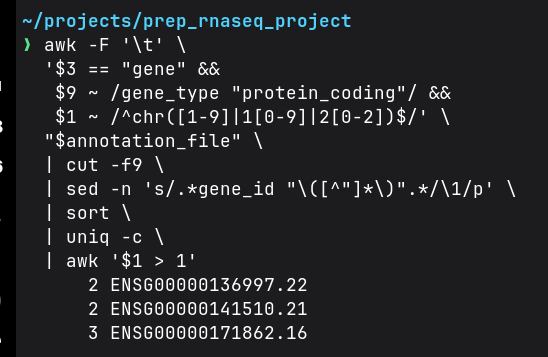

## Step 6 — Extract Coordinates and Calculate Genomic Span

Now we need:

- chromosome
- start
- end
- span

For a GTF record:

```
$1 = chromosome
$4 = start
$5 = end
```

For inclusive GTF coordinates:

```
span = end - start + 1
```

## Calculating Genomic Span (Cont.)

So:

```bash
awk -F '\t' '$3 == "gene" &&
$9 ~ /gene_type "protein_coding"/ &&
$1 ~ /^chr([1-9]|1[0-9]|2[0-2])$/ {
  print $1, $4, $5, $5-$4+1
}
' "$annotation_file"
```

[figure not shown]

The last column is **calculated** rather than extracted.

That is where `awk` becomes especially useful:

> read fields → apply logic → calculate → print

## Nice. Where would we go from here?

With these tools, you can perform further analysis by yourself, then redirect the output directly to a file using **output redirection**.

By now, you probably noticed that some commands, especially the `awk` pipeline, were getting harder to read. This is often the point where a script or a **higher-level language** such as Python becomes useful.

[figure not shown]

[figure not shown]

## Example: When You Should Consider Using Another Tool

Instead of printing the results to the terminal, we want to create a TSV report.

```bash
report_file="results/annotation_audit.tsv"
```

Then:

```bash
awk -F '\t' '
BEGIN {
    OFS = "\t"
    print "gene_id", "gene_name", "chromosome", "start", "end", "span_bp"
}
$3 == "gene" && $9 ~ /gene_type "protein_coding"/ && $1 ~ /^chr([1-9]|1[0-9]|2[0-2])$/ {
    gene_id = $9
    sub(/.*gene_id "/, "", gene_id)
    sub(/".*/, "", gene_id)
    gene_name = $9
    sub(/.*gene_name "/, "", gene_name)
    sub(/".*/, "", gene_name)
    span = $5 - $4 + 1
    print gene_id, gene_name, $1, $4, $5, span
}
' "$annotation_file" > "$report_file"
```

The results are good, but **reading and maintaining** this kind of code would be a pain.